# Comparing Future Climate Scenarios (Python Edition)

## Testing Example

This test leverages a dataset compiled by

> De Vito, S., E. Massera, M. Piga, L. Martinotto, G. Di Francia, 2008: On field calibration of an electronic nose for benzene estimation in an urban pollution monitoring scenario, *Sensors and Actuators B: Chemical*, **129** (2), 750-757, [doi: 10.1016/j.snb.2007.09.060](https://www.sciencedirect.com/science/article/abs/pii/S0925400507007691).

The dataset is maintained by the Univ of California at Irvine, Machine Learning Repository ([doi: 10.24432/C59K5F](https://doi.org/10.24432/C59K5F))

Here, the data is extracted for two Benzine samples (a training sample with 70 samples and a testing sample of 30 samples) at 0700 UTC between 2004-March-11 and 2005-April-04.

### Support Libraries for Demonstration

- [numpy](https://numpy.org/doc/stable/reference/generated/numpy.nansum.html): The Go-To Python Library for Arrays and Basic Math Operation
- [pandas](https://pandas.pydata.org/docs/): Our Go-To Library for Tabular Data.

```python
#########################################
#
# Demonstration Libraries
#

import pandas as pd

#
#########################################
```

```python
#########################################
#
# Demonstration Libraries
#

url_xlsx = "https://kyrill.ias.sdsmt.edu:8080/thredds/fileServer/CLASS_Examples/CEE_284_Area/Statistics/Air_Quality_Extraction_H0700.xlsx"

training = pd.read_excel(io         = url_xlsx,
                         sheet_name = "Training").  \
              set_index("Time")

testing  = pd.read_excel(io         = url_xlsx,
                         sheet_name = "Testing").  \
              set_index("Time")

display(training)
display(testing)
#
#########################################
```

| Time | Sample | Month | Hour | C6H6 (μg/m³) | CO (mg/m³) | NOx (ppb) | NO2 (μg/m³) | T (° C) | RH (%) | AH (g/kg) |
| --- | --- | --- | --- | --- | --- | --- | --- | --- | --- | --- |
| 2004-04-07 07:00:00 | Train | Apr | 7 | 12.935403 | 2.8 | 152.0 | 111.0 | 14.300 | 58.175 | 0.943075 |
| 2004-04-12 07:00:00 | Train | Apr | 7 | 0.945425 | 0.5 | 39.0 | 53.0 | 13.475 | 50.100 | 0.770567 |
| 2004-04-13 07:00:00 | Train | Apr | 7 | 19.123453 | 3.9 | 328.0 | 130.0 | 10.975 | 64.150 | 0.839760 |
| 2004-05-02 07:00:00 | Train | May | 7 | 4.755590 | 0.8 | 48.0 | 46.0 | 14.300 | 66.175 | 1.072763 |
| 2004-05-04 07:00:00 | Train | May | 7 | 23.037221 | 4.5 | 302.0 | 109.0 | 16.550 | 78.000 | 1.457225 |
| ... | ... | ... | ... | ... | ... | ... | ... | ... | ... | ... |
| 2005-03-03 07:00:00 | Train | Mar | 7 | 6.742318 | 1.4 | 262.8 | 135.5 | 2.850 | 75.575 | 0.574151 |
| 2005-03-04 07:00:00 | Train | Mar | 7 | 7.486889 | 1.9 | 408.9 | 138.7 | 3.125 | 77.300 | 0.598485 |
| 2005-03-05 07:00:00 | Train | Mar | 7 | 2.042536 | 0.8 | 167.5 | 132.2 | 4.625 | 54.575 | 0.468217 |
| 2005-03-21 07:00:00 | Train | Mar | 7 | 6.074366 | 1.3 | 270.2 | 112.8 | 12.800 | 68.050 | 1.002346 |
| 2005-03-26 07:00:00 | Train | Mar | 7 | 5.691083 | 1.1 | 174.6 | 79.7 | 16.100 | 69.500 | 1.262319 |

70 rows × 10 columns

| Time | Sample | Month | Hour | C6H6 (μg/m³) | CO (mg/m³) | NOx (ppb) | NO2 (μg/m³) | T (° C) | RH (%) | AH (g/kg) |
| --- | --- | --- | --- | --- | --- | --- | --- | --- | --- | --- |
| 2004-04-06 07:00:00 | Test | Apr | 7 | 24.134258 | 4.5 | 329.0 | 134.0 | 15.300 | 55.225 | 0.953788 |
| 2004-04-27 07:00:00 | Test | Apr | 7 | 23.419668 | 4.1 | 314.0 | 122.0 | 15.900 | 48.525 | 0.870351 |
| 2004-05-01 07:00:00 | Test | May | 7 | 6.451626 | 1.2 | 75.0 | 67.0 | 16.875 | 66.550 | 1.268826 |
| 2004-05-03 07:00:00 | Test | May | 7 | 21.128692 | 3.4 | 283.0 | 101.0 | 16.825 | 62.450 | 1.186945 |
| 2004-05-07 07:00:00 | Test | May | 7 | 19.779412 | 3.7 | 214.0 | 106.0 | 14.900 | 56.900 | 0.958184 |
| 2004-05-14 07:00:00 | Test | May | 7 | 22.780588 | 3.7 | 272.0 | 140.0 | 18.475 | 49.375 | 1.039693 |
| 2004-05-15 07:00:00 | Test | May | 7 | 9.061727 | 1.4 | 106.0 | 68.0 | 16.025 | 47.375 | 0.856424 |
| 2004-05-20 07:00:00 | Test | May | 7 | 19.618987 | 2.8 | 188.0 | 97.0 | 16.600 | 55.950 | 1.048554 |
| 2004-06-08 07:00:00 | Test | Jun | 7 | 19.370545 | 3.3 | 309.0 | 100.0 | 19.525 | 57.725 | 1.296638 |
| 2004-06-13 07:00:00 | Test | Jun | 7 | 1.279695 | 0.4 | 25.0 | 36.0 | 21.375 | 47.750 | 1.200534 |
| 2004-06-29 07:00:00 | Test | Jun | 7 | 23.496479 | 3.4 | 228.0 | 102.0 | 24.725 | 49.475 | 1.520097 |
| 2004-07-08 07:00:00 | Test | Jul | 7 | 16.944141 | 2.2 | 231.0 | 115.0 | 25.875 | 37.375 | 1.228885 |
| 2004-07-15 07:00:00 | Test | Jul | 7 | 15.564889 | 2.3 | 168.0 | 108.0 | 21.325 | 48.350 | 1.211945 |
| 2004-08-11 07:00:00 | Test | Aug | 7 | 9.468788 | 1.4 | 89.0 | 42.0 | 26.800 | 60.525 | 2.100800 |
| 2004-08-12 07:00:00 | Test | Aug | 7 | 10.956517 | 1.7 | 87.0 | 60.0 | 26.400 | 61.725 | 2.092947 |
| 2004-09-19 07:00:00 | Test | Sep | 7 | 4.809205 | 1.0 | 139.0 | 62.0 | 16.850 | 66.825 | 1.272082 |
| 2004-09-27 07:00:00 | Test | Sep | 7 | 26.900112 | 5.5 | 799.0 | 132.0 | 15.000 | 57.700 | 0.977823 |
| 2004-10-28 07:00:00 | Test | Oct | 7 | 19.994179 | 3.4 | 640.0 | 88.0 | 15.725 | 76.425 | 1.355764 |
| 2004-10-29 07:00:00 | Test | Oct | 7 | 15.929432 | 2.9 | 366.0 | 111.0 | 20.175 | 66.925 | 1.564267 |
| 2004-11-14 07:00:00 | Test | Nov | 7 | 0.212798 | 0.2 | 25.0 | 21.0 | 10.175 | 41.925 | 0.520914 |
| 2004-11-18 07:00:00 | Test | Nov | 7 | 9.890093 | 2.1 | 531.0 | 162.0 | 6.825 | 74.500 | 0.741531 |
| 2004-11-29 07:00:00 | Test | Nov | 7 | 9.817125 | 2.0 | 325.0 | 90.0 | 8.725 | 83.700 | 0.945385 |
| 2005-01-01 07:00:00 | Test | Jan | 7 | 4.458207 | 1.4 | 168.1 | 96.7 | 3.025 | 60.700 | 0.466738 |
| 2005-01-20 07:00:00 | Test | Jan | 7 | 2.741115 | 1.0 | 181.9 | 104.4 | 7.450 | 55.250 | 0.573390 |
| 2005-02-03 07:00:00 | Test | Feb | 7 | 4.247511 | 0.6 | 215.6 | 133.9 | 1.350 | 63.125 | 0.432208 |
| 2005-02-21 07:00:00 | Test | Feb | 7 | 5.462115 | 1.2 | 183.3 | 123.1 | 4.200 | 80.900 | 0.674249 |
| 2005-02-24 07:00:00 | Test | Feb | 7 | 5.482765 | 1.5 | 289.7 | 169.5 | 3.750 | 83.775 | 0.677052 |
| 2005-02-26 07:00:00 | Test | Feb | 7 | 1.912104 | 1.0 | 143.7 | 108.2 | 5.725 | 54.325 | 0.502158 |
| 2005-02-28 07:00:00 | Test | Feb | 7 | 0.655256 | 0.4 | 88.8 | 65.5 | 2.500 | 52.700 | 0.390810 |
| 2005-03-10 07:00:00 | Test | Mar | 7 | 6.423963 | 1.3 | 249.1 | 100.0 | 4.325 | 76.075 | 0.639467 |

## Executing the Function

Here we will demonstrate all three basic statistical tests, challenging the Testing sample against the Training sample.

```
╔═══════════════════════════════════════════════════
║╭──────────────────────────────────────────────
║│  Welch's t-Test Report (ɑ=0.05)
║│ Variable : Benzine Concentration [μg/m³]
║│       Ho : Testing = Training
║│       Ha : Testing ≠ Training
║│        t : 1.1986856285319138
║│  t₍₁₋½ₐ₎ : 2.0094557942758993
║│        p : 0.2364019304228048 0.23640193042280466
║│   Result : Ho cannot be rejected; Testing = Training
║╰──────────────────────────────────────────────
```

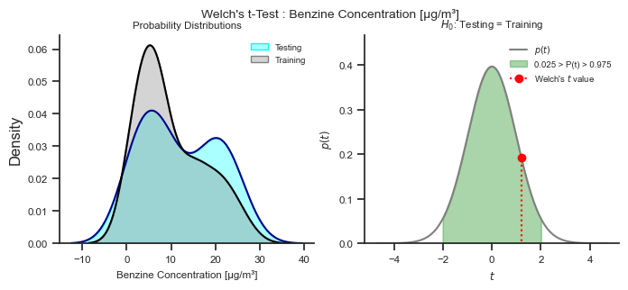

```
╚═══════════════════════════════════════════════════

Two-Tail Function Output
```

```
{'t': 1.1986856285319138,
 'p': 0.2364019304228048,
 'df': 49.11541799673543,
 'Result': 'Ho cannot be rejected; Testing = Training'}
```

```
╔═══════════════════════════════════════════════════
║╭──────────────────────────────────────────────
║│  Welch's t-Test Report (ɑ=0.05)
║│ Variable : Benzine Concentration [μg/m³]
║│       Ho : Testing ≤ Training
║│       Ha : Testing > Training
║│        t : 1.1986856285319138
║│   t₍₁₋ₐ₎ : 1.676474979734221
║│        p : 0.1182009652114024 0.11820096521140233
║│   Result : Ho cannot be rejected; Testing ≤ Training
║╰──────────────────────────────────────────────
```

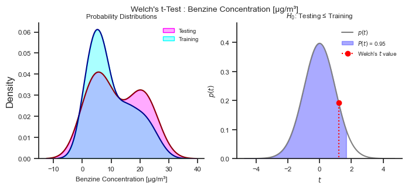

```
╚═══════════════════════════════════════════════════

Right-Tail Function Output
```

```
{'t': 1.1986856285319138,
 'p': 0.1182009652114024,
 'df': 49.11541799673543,
 'Result': 'Ho cannot be rejected; Testing ≤ Training'}
```

```
╔═══════════════════════════════════════════════════
║╭──────────────────────────────────────────────
║│  Welch's t-Test Report (ɑ=0.05)
║│ Variable : Benzine Concentration [μg/m³]
║│       Ho : Testing ≥ Training
║│       Ha : Testing < Training
║│        t : 1.1986856285319138
║│   t₍₁₋ₐ₎ : -1.6764749797342218
║│        p : 0.8817990347885977 0.8817990347885977
║│   Result : Ho cannot be rejected; Testing ≥ Training
║╰──────────────────────────────────────────────
```

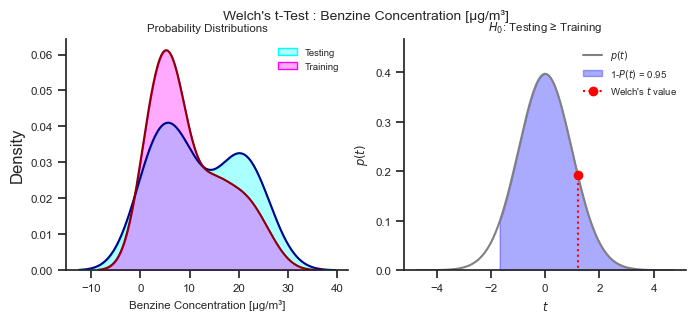

```
╚═══════════════════════════════════════════════════

Left-Tail Function Output
```

```
{'t': 1.1986856285319138,
 'p': 0.8817990347885977,
 'df': 49.11541799673543,
 'Result': 'Ho cannot be rejected; Testing ≥ Training'}
```

```python
#########################################
#
# Demonstration of Function
#

#
# Two-Tail Function Output
#

T_test_Ha_Testing_ne_Training = \
    Welchs_t_Test(x1 =         testing["C6H6 (μg/m³)"],
                  x2 =        training["C6H6 (μg/m³)"],
                test =                     "two-sided",
       variable_name = "Benzine Concentration [μg/m³]",
             x1_name =                       "Testing",
             x2_name =                      "Training",
               alpha =                            0.05)

print("Two-Tail Function Output")
display(T_test_Ha_Testing_ne_Training)
print("")
print("")

#
# Right-Tail Function Output
#

T_test_Ha_Testing_gt_Training = \
    Welchs_t_Test(x1 =         testing["C6H6 (μg/m³)"],
                  x2 =        training["C6H6 (μg/m³)"],
                test =                       "greater",
       variable_name = "Benzine Concentration [μg/m³]",
             x1_name =                       "Testing",
             x2_name =                      "Training",
               alpha =                            0.05)

print("Right-Tail Function Output")
display(T_test_Ha_Testing_gt_Training)
print("")
print("")

#
# Left-Tail Function Output
#

T_test_Ha_Testing_lt_Training = \
    Welchs_t_Test(x1 =         testing["C6H6 (μg/m³)"],
                  x2 =        training["C6H6 (μg/m³)"],
                test =                          "less",
       variable_name = "Benzine Concentration [μg/m³]",
             x1_name =                       "Testing",
             x2_name =                      "Training",
               alpha =                            0.05)

print("Left-Tail Function Output")
display(T_test_Ha_Testing_lt_Training)
print("")
print("")

#
#########################################
```

## Version Information

- version_information: Robert Johansson's Version Information Utility

```python
#########################################
#
# Version Information Utility
#

%load_ext version_information

%version_information numpy, scipy, matplotlib, pandas, version_information

#
#########################################
```

| Software | Version |
| --- | --- |
| Python | 3.12.8 64bit [Clang 18.1.8 ] |
| IPython | 9.0.2 |
| OS | macOS 15.3.1 arm64 arm 64bit |
| numpy | 1.26.4 |
| scipy | 1.15.2 |
| matplotlib | 3.9.4 |
| pandas | 2.2.3 |
| version_information | 1.0.4 |
| Wed Mar 12 12:38:18 2025 MDT |  |